# HW6

Mohammad Roghani

Farvardin 19, 1397 AP

# Q1

```r
library(Hmisc)
library(dplyr)
house = read.csv("train.csv")
colnames(house)[44] = "X1stFlrSF"
colnames(house)[45] = "X2stFlrSF"
numeric_columns = sapply(house, is.numeric)
cor_matrix = as.data.frame(rcorr(as.matrix(house[,numeric_columns]))$r)
cor_matrix = add_rownames(cor_matrix, "Name")
best_variables = cor_matrix %>% arrange(desc(SalePrice)) %>% head(11) %>% select(Name)
best_variables
```

```
## # A tibble: 11 x 1
##    Name
##    <chr>
##  1 SalePrice
##  2 OverallQual
##  3 GrLivArea
##  4 GarageCars
##  5 GarageArea
##  6 TotalBsmtSF
##  7 X1stFlrSF
##  8 FullBath
##  9 TotRmsAbvGrd
## 10 YearBuilt
## 11 YearRemodAdd
```

# Q2

با توجه به نمودارها دو متغیر TotalBsmtSF و X1stFlrSF با متغیر SalePrice رابطه خطی ندارند.

```r
library(car)
```

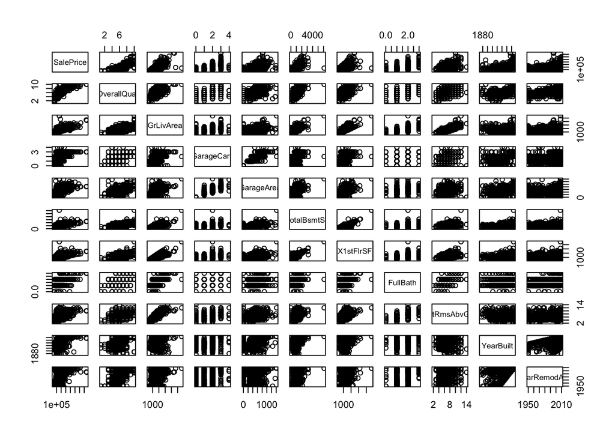

```r
plot(house %>% select(SalePrice, OverallQual, GrLivArea, GarageCars, GarageArea, TotalBsmtSF, X1stFlrSF, FullBath, TotRmsAbvGrd, YearBuilt, YearRemodAdd))
```

# Q3

```r
line = lm(SalePrice ~ OverallQual + GrLivArea + GarageCars + GarageArea + TotalBsmtSF + X1stFlrSF + FullBath + TotRmsAbvGrd + YearBuilt + YearRemodAdd, data = house)
summary(line)
```

```
##
## Call:
## lm(formula = SalePrice ~ OverallQual + GrLivArea + GarageCars +
##     GarageArea + TotalBsmtSF + X1stFlrSF + FullBath + TotRmsAbvGrd +
##     YearBuilt + YearRemodAdd, data = house)
##
## Residuals:
##     Min      1Q  Median      3Q     Max
## -489958  -19316   -1948   16020  290558
##
## Coefficients:
##                Estimate Std. Error t value Pr(>|t|)
## (Intercept)  -1.186e+06  1.291e+05  -9.187  < 2e-16 ***
## OverallQual   1.960e+04  1.190e+03  16.472  < 2e-16 ***
## GrLivArea     5.130e+01  4.233e+00  12.119  < 2e-16 ***
## GarageCars    1.042e+04  3.044e+03   3.422 0.000639 ***
## GarageArea    1.495e+01  1.031e+01   1.450 0.147384
## TotalBsmtSF   1.986e+01  4.295e+00   4.625 4.09e-06 ***
## X1stFlrSF     1.417e+01  4.930e+00   2.875 0.004097 **
## FullBath     -6.791e+03  2.682e+03  -2.532 0.011457 *
## TotRmsAbvGrd  3.310e+01  1.119e+03   0.030 0.976404
## YearBuilt     2.682e+02  5.035e+01   5.328 1.15e-07 ***
## YearRemodAdd  2.965e+02  6.363e+01   4.659 3.47e-06 ***
## ---
## Signif. codes:  0 '***' 0.001 '**' 0.01 '*' 0.05 '.' 0.1 ' ' 1
##
## Residual standard error: 37920 on 1449 degrees of freedom
## Multiple R-squared:  0.7737, Adjusted R-squared:  0.7721
## F-statistic: 495.4 on 10 and 1449 DF,  p-value: < 2.2e-16
```

# Q4

با توجه به نمودار normal Q-Q چون ابتدا و انتهای آن روی خط قرار ندارد نتیجه می دهد که خطا از توزیع نرمال پیروی نمی کند. همچنین با توجه به نمودار Residuals vs Fited می توان فهمید که واریانس خطا ثابت نیست زیرا در آخر نمودار تقریبا در اکثر موارد مقدار residual مثبت است و بهتر بود که خط قرمز در آخر بالا تر قرار می گرفت و متغیرها به خوبی تابع واقعی را توصیف نمی کنند.

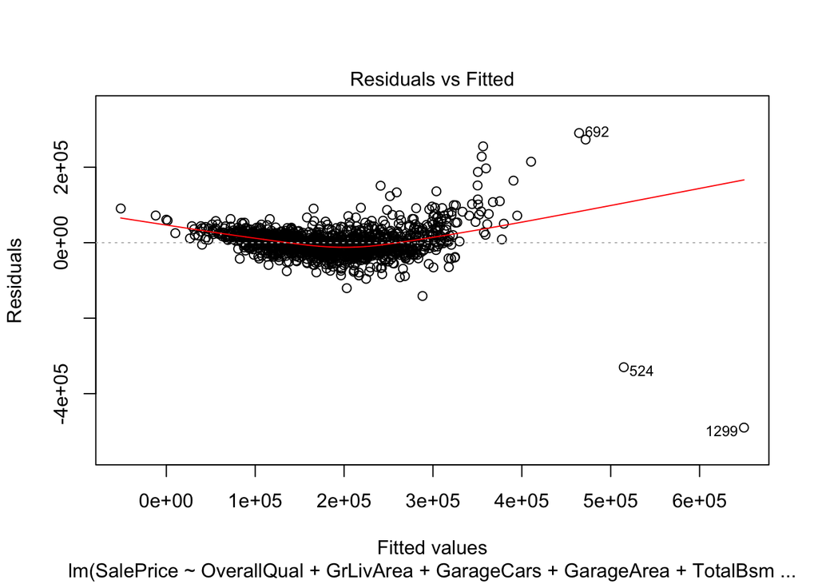

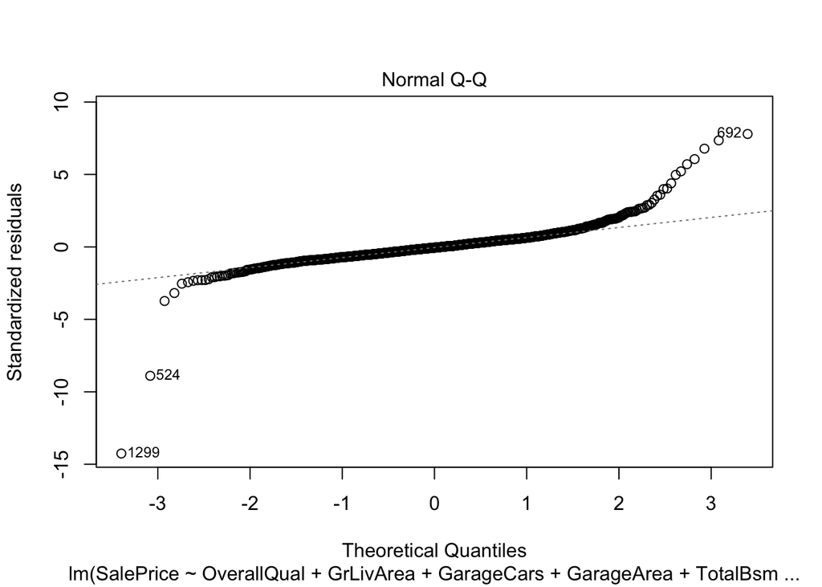

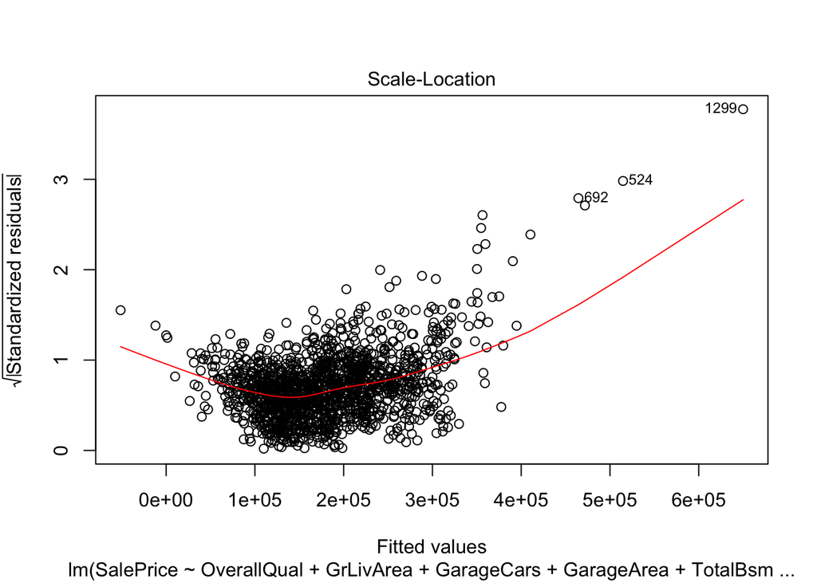

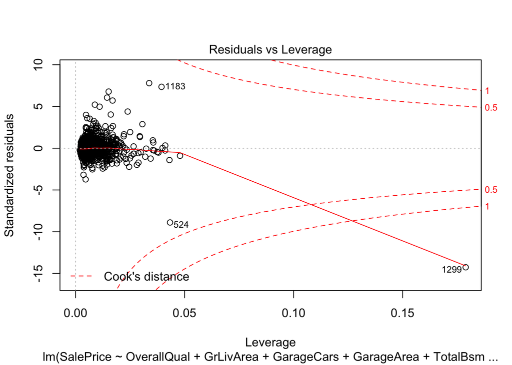

```r
plot(line)
```

# Q5

r-square نشاند می دهد که داده ما چقدر به مقدار تقریب زده نزدیک است و این مقدار همیشه بین ۰ و ۱ است و چون مقدار به دست آمده ۰.۷۷ است نتیجه می دهد که مدل ما مدل خوبی است. در واقع به ما نشان می دهد که ۷۷ درصد واریانس وجود داشته توسط متغیر ها مدل شده اند. چون مقدار f-statistic خیلی بزرگ تر از ۱ است در نتیجه می توان گفت که به متغیرها وابسته است و مدل خوبی است.

```r
summary(line)$r.squared
```

```
## [1] 0.7736928
```

```r
summary(line)$fstatistic
```

```
##     value     numdf     dendf
##  495.3802   10.0000 1449.0000
```

# Q6

با توجه به p-value های به دست آمده ضریب تاثیر را 0.01 در نظر می گیریم و و متغیرهایی که p-value آن ها بیشتر است را حذف می کنیم.

```r
line = lm(SalePrice ~ OverallQual + GrLivArea + GarageCars + TotalBsmtSF + X1stFlrSF + YearBuilt + YearRemodAdd, data = house)
summary(line)
```

```
##
## Call:
## lm(formula = SalePrice ~ OverallQual + GrLivArea + GarageCars +
##     TotalBsmtSF + X1stFlrSF + YearBuilt + YearRemodAdd, data = house)
##
## Residuals:
##     Min      1Q  Median      3Q     Max
## -471221  -19922   -1681   16246  291326
##
## Coefficients:
##                Estimate Std. Error t value Pr(>|t|)
## (Intercept)  -1.075e+06  1.217e+05  -8.833  < 2e-16 ***
## OverallQual   1.949e+04  1.190e+03  16.377  < 2e-16 ***
## GrLivArea     4.768e+01  2.713e+00  17.576  < 2e-16 ***
## GarageCars    1.381e+04  1.820e+03   7.586 5.85e-14 ***
## TotalBsmtSF   2.174e+01  4.249e+00   5.117 3.53e-07 ***
## X1stFlrSF     1.407e+01  4.925e+00   2.856  0.00435 **
## YearBuilt     2.292e+02  4.799e+01   4.777 1.96e-06 ***
## YearRemodAdd  2.768e+02  6.337e+01   4.367 1.35e-05 ***
## ---
## Signif. codes:  0 '***' 0.001 '**' 0.01 '*' 0.05 '.' 0.1 ' ' 1
##
## Residual standard error: 38010 on 1452 degrees of freedom
## Multiple R-squared:  0.7722, Adjusted R-squared:  0.7711
## F-statistic: 703.2 on 7 and 1452 DF,  p-value: < 2.2e-16
```

# Q7

با توجه به نمودار normal Q-Q چون ابتدا و انتهای آن روی خط قرار ندارد نتیجه می دهد که خطا از توزیع نرمال پیروی نمی کند. همچنین با توجه به نمودار Residuals vs Fited می توان فهمید که واریانس خطا ثابت نیست زیرا در آخر نمودار تقریبا در اکثر موارد مقدار residual مثبت است و بهتر بود که خط قرمز در آخر بالا تر قرار می گرفت و متغیرها به خوبی تابع واقعی را توصیف نمی کنند. همچنین با توجه به نمودار آخر چون همه ی ستون ها تقریبا زیر خط آبی هستند در نتیجه متغیرها نسبت به یکدیگر آزاد هستند زیرا همبستگی های به دست آمده کم است.

```r
library(car)
line = lm(SalePrice ~ OverallQual + GrLivArea + GarageCars + TotalBsmtSF + X1stFlrSF + YearBuilt + YearRemodAdd, data = house)
ncvTest(line)
```

```
## Non-constant Variance Score Test
## Variance formula: ~ fitted.values
## Chisquare = 2777.921    Df = 1     p = 0
```

```r
shapiro.test(line$residuals)
```

```
##
##  Shapiro-Wilk normality test
##
## data:  line$residuals
## W = 0.81207, p-value < 2.2e-16
```

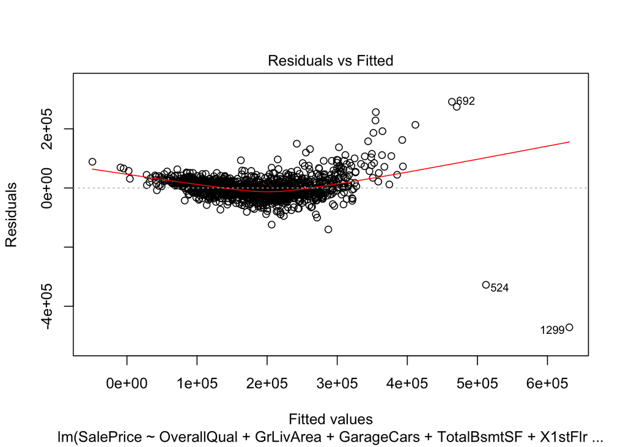

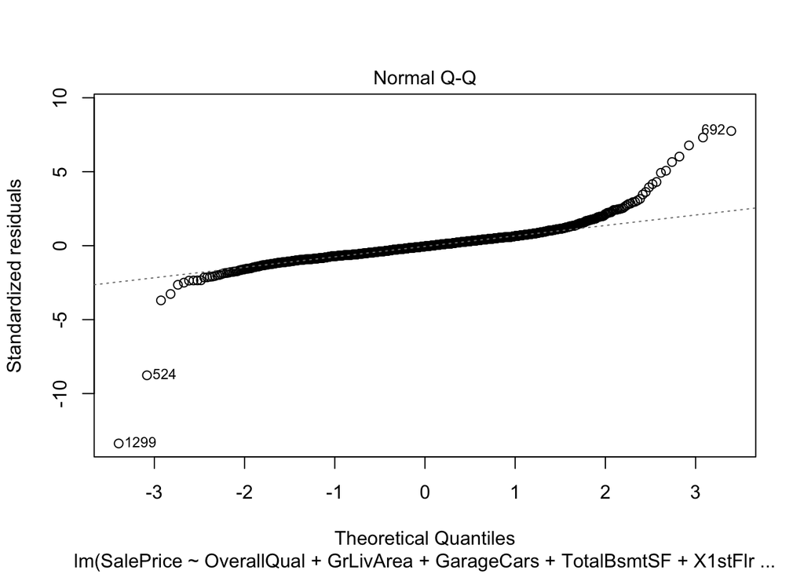

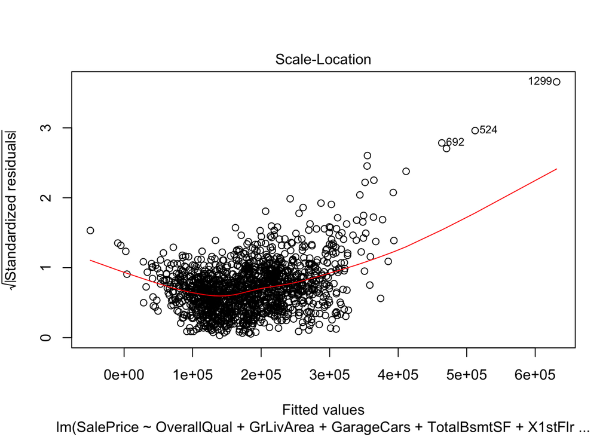

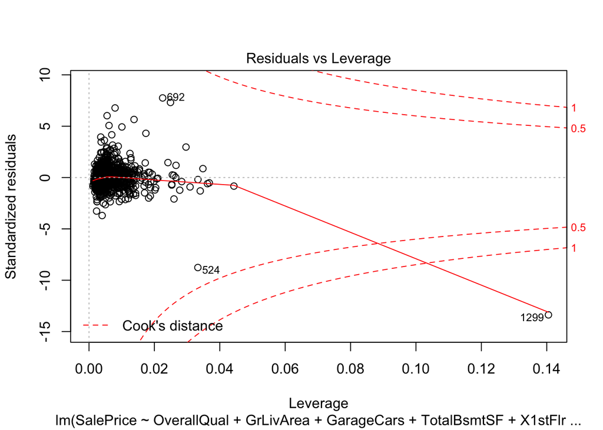

```r
plot(line)
```

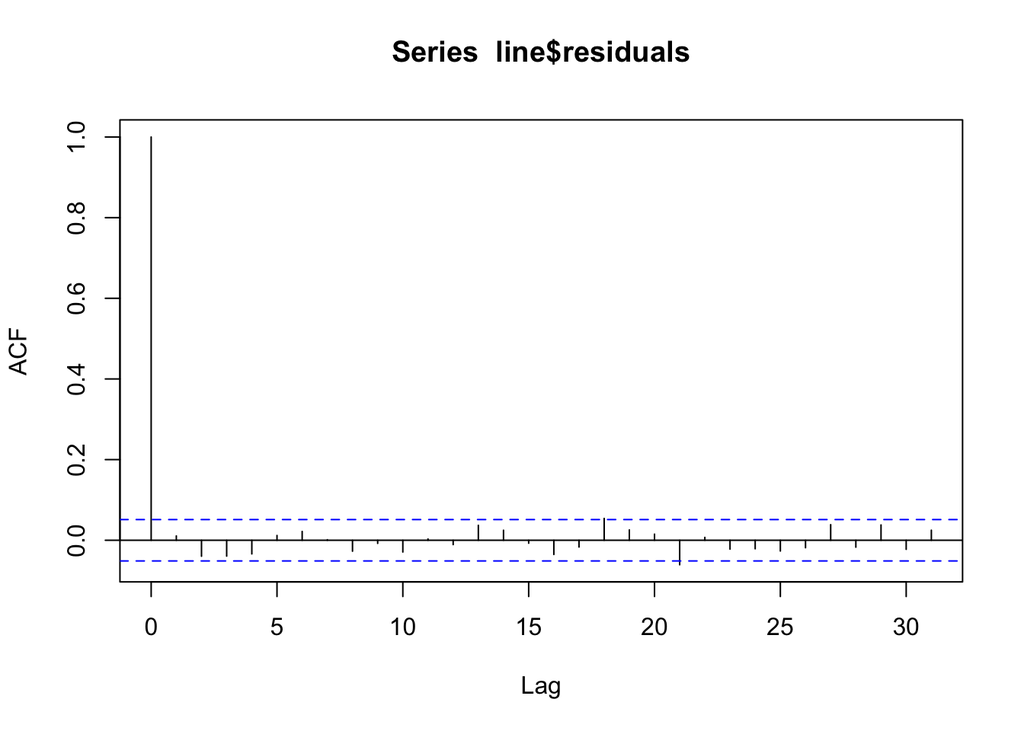

```r
acf(line$residuals)
```

# Q8

برای به دست آوردن cross validation با ۵ دسته از تابع trainControl که در کتابخانه caret قرار دارد استفاده می کنیم.

```r
library(caret)
kfold = trainControl(method = "cv", number = 5)
new_line = train(SalePrice ~ OverallQual + GrLivArea + GarageCars + TotalBsmtSF + X1stFlrSF + YearBuilt + YearRemodAdd, data = house, trControl = kfold, method="lm")
print(new_line)
```

```
## Linear Regression
##
## 1460 samples
##    7 predictor
##
## No pre-processing
## Resampling: Cross-Validated (5 fold)
## Summary of sample sizes: 1169, 1168, 1168, 1168, 1167
## Resampling results:
##
##   RMSE      Rsquared   MAE
##   38815.22  0.7648747  24405.32
##
## Tuning parameter 'intercept' was held constant at a value of TRUE
```

# Q9

با توجه به نمودارهای شکل ۲ می توان فهمید که OverallQual رابطه نمایی با قیمت دارد.

```r
best_fit = lm(SalePrice ~ exp(OverallQual) + GrLivArea + GarageCars + TotalBsmtSF + X1stFlrSF + YearBuilt + YearRemodAdd , data = house)
```

# Q10

```r
library(readr)
best_fit = lm(SalePrice ~ exp(OverallQual) + GrLivArea + TotalBsmtSF + X1stFlrSF + YearBuilt + YearRemodAdd , data = house)
test = read.csv("test.csv")
colnames(test)[44] = "X1stFlrSF"
ans = data.frame(test$Id)
ans$SalePrice = predict(best_fit, test)
colnames(ans) = c("Id", "SalePrice")
ans[is.na(ans)] = 178728
write_csv(ans,"ans.csv")
```